# More Classification

Support Vector Machine, Kernels, more classification metrics

STOR 390

# This lecture

- maximal margin classifier (MM)
  - AKA hard margin support vector machine
- support vector machine (SVM)
  - AKA soft margin SVM
- kernels
- other classification metrics

# Binary classes

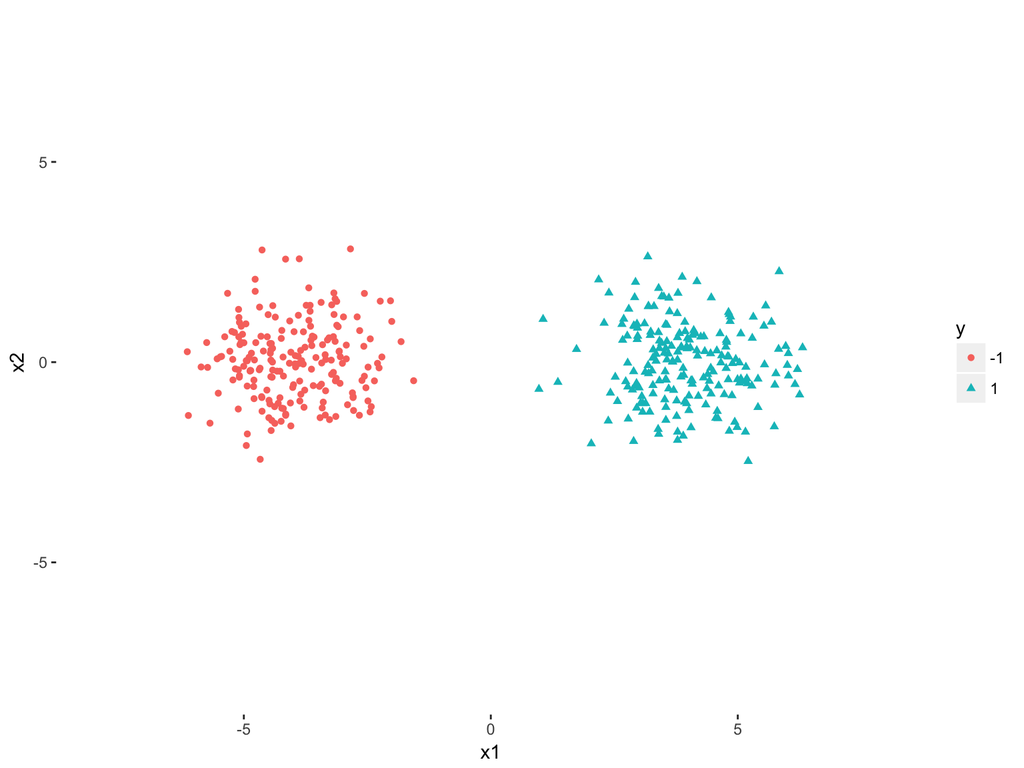

# Linear classifiers

- nerest centroid
- split the two classes by a line (hyperplane)

# linearly separable data

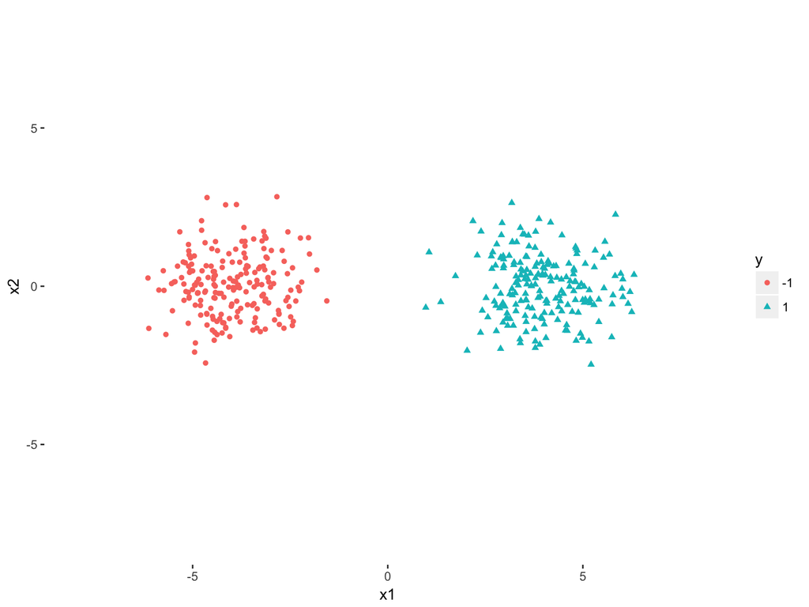

# Which separating hyperplane?

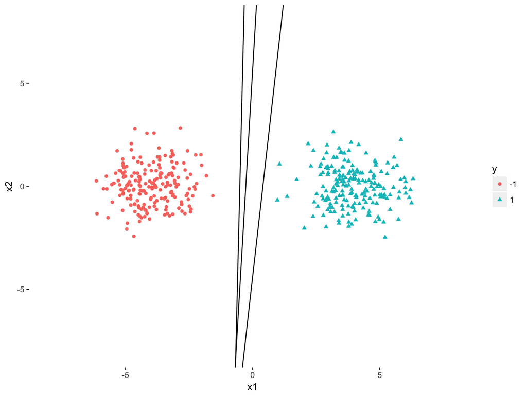

# The Margin

Call the distance from the separating hyperplane to the nearest data point the *margin*.

# The Margin

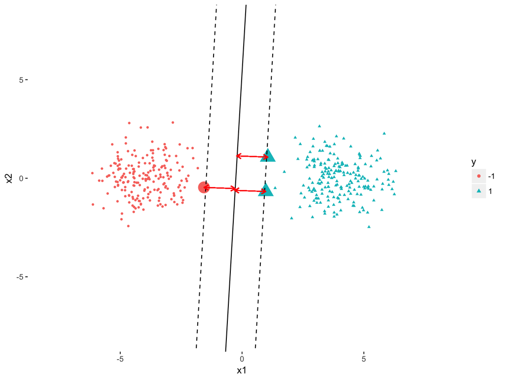

# Maximal Margin classifier (intuition)

- data should be as far away from the separating hyperplane as possible.

# Maximal Margin classifier (words)

- The separating hyperplane that maximizes the margin.
  - Maximizes the minimum distance from the data points to the separating hyperplane.
- **Warning**: only defined when the data are linearly separable.
- See ISLR chapter 9 for details.

# Non-linearly separable data

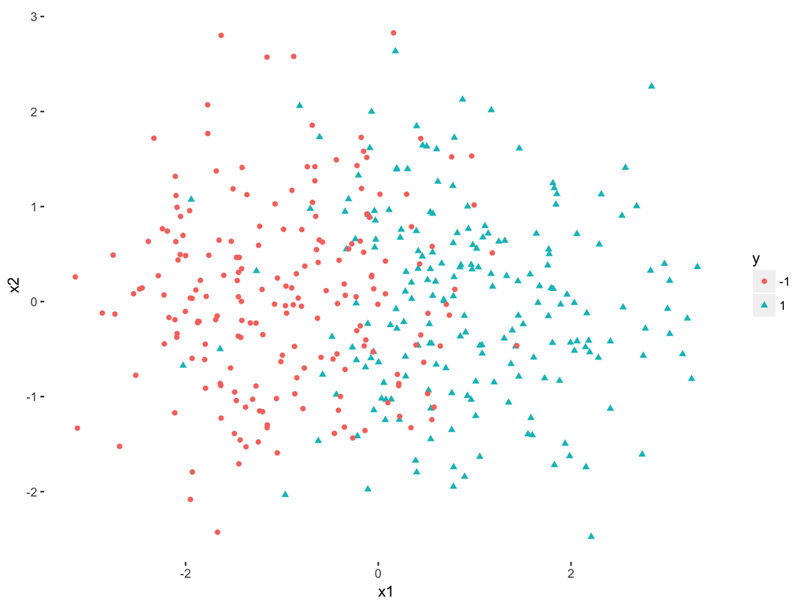

# Soft margin SVM (intuition)

A good linear classifier should aim to put points

- on the correct side of the separating hyperplane far away from the separating hyperplane
- on the wrong side of the separating hyperplane close to the separating hyperplane

# Soft margin SVM

- Allow points to be on the wrong side of the separating hyperplane, but penalize them.
- Keep as many points on the correct side of the separating hyperplane as possible.

# Two competing objectives

- maximize the margin
- penalize disobedient points

# Balance competing objectives

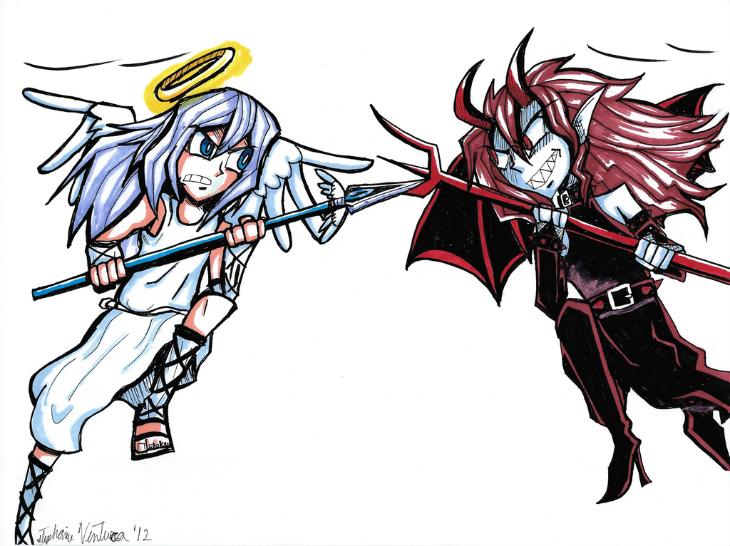

[image from http://img04.deviantart.net/a1bc/i/2012/189/4/8/angel_vs_devil_by_sakura_wind-d568jp4.png]

# Tuning parameter!

- SVM comes with a tuning parameter $C >0$ that controls the balance between the two competing objectives.
- Larger values of $C$ make SVM care more about “bad” points
- Smaller values $C$ mean SVM has more chill about misclassified points

# C large

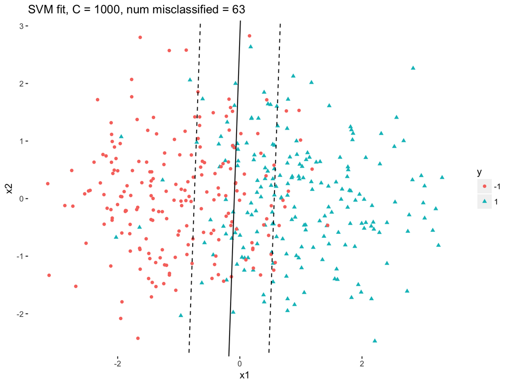

# C moderate

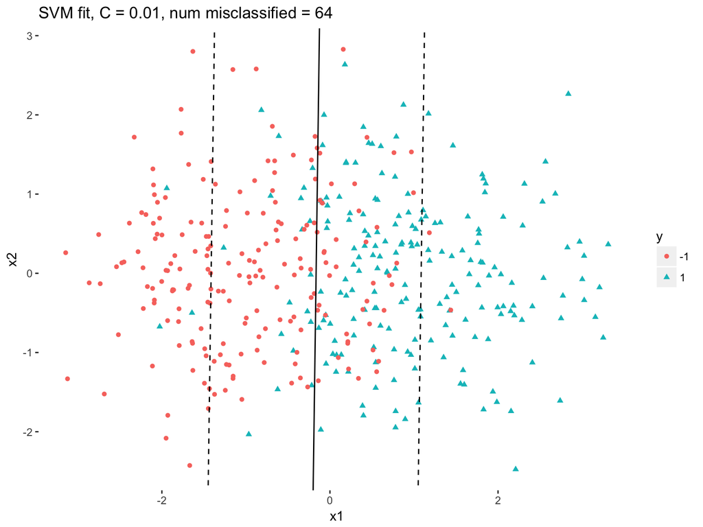

# C small

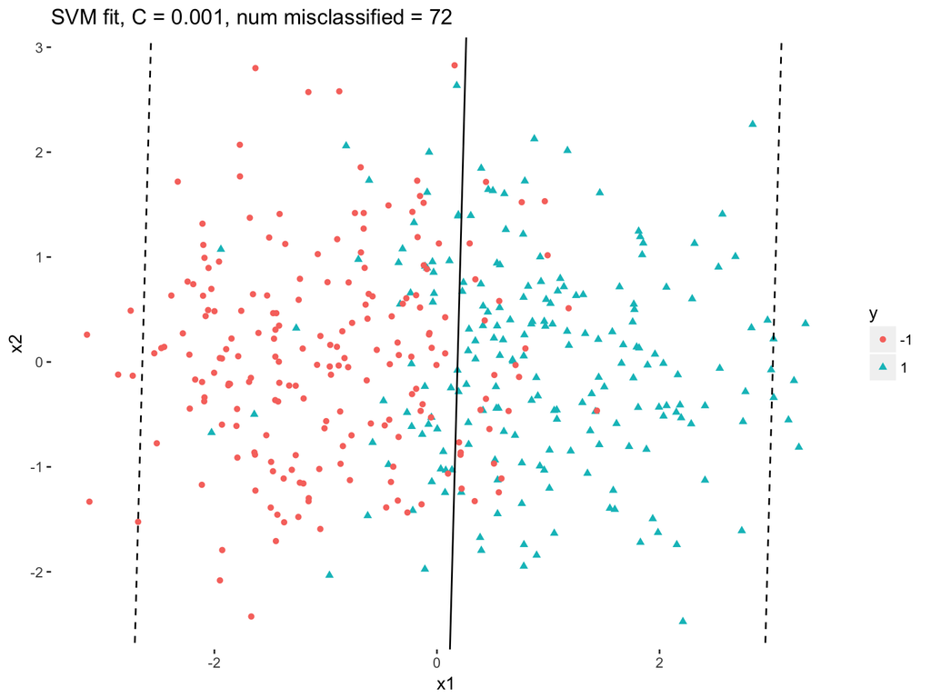

# Fitting SVM

- cannot be done in closed form
- requires a numerical optimization algorithm (quadratic programming)

# e1071 package

- open source implementation of SVM
- see documentation `?svm()`

# Some training data

```r
# this function comes from the synthetic_distributions.R package
train <- two_class_guasssian_meatballs(n_pos=200, n_neg=200,
                                       mu_pos=c(1,0), mu_neg=c(-1,0),
                                       sigma_pos=diag(2), sigma_neg=diag(2),
                                       seed=103)

train
```

```
## # A tibble: 400 × 3
##             x1         x2      y
##          <dbl>      <dbl> <fctr>
## 1   2.15074931 -0.4792060      1
## 2  -0.08786829  1.6166332      1
## 3   1.76506913 -0.1514896      1
## 4   0.61865671  1.2622023      1
## 5   1.07803836 -0.5458768      1
## 6   0.85736662  0.3856852      1
## 7   1.75866283  0.3809878      1
## 8   2.21017318 -2.4745634      1
## 9   0.96406375  0.3872157      1
## 10 -0.60946315  1.7316120      1
## # ... with 390 more rows
```

# SVM code

```r
# fit SVM
svmfit <- svm(y ~ ., # R's formula notation
              data=train, # data frame to use
              cost=10, # set the tuning paramter
              scale=FALSE,
              type='C-classification',
              shrinking=FALSE,
              kernel='linear')
```

# main arguments

- `data=train` says fit SVM using the data stored in the `train` data frame.
- The `svm()` function uses R’s formula notation. Recall from linear regression `y ~ .` means fit `y` on all the rest of the columns of data. We could have equivalently used `y ~ x1 + x2`.
- `cost = 10` fixes the tuning parameter $C$ to 10. The tuning parameter $C$ is also sometimes called a *cost* parameter.
- `shrinking=FALSE` I’m not sure what this does, but I don’t want anything extra to happen so I told it to stop.

# Other arguments

- `scale = FALSE` says **please do not center and scale** our data. `svm()` applies some [preprocessing](http://scikit-learn.org/stable/modules/preprocessing.html) to the data by default. While preprocessing (e.g. center and scale) is often a good thing to do, I strongly disagree with making this the default behavior.
- `type='C-classification'` tells `svm()` to do classification. It turns out SVM can be used to do other things than classification](http://kernelsvm.tripod.com/).
- `kernel='linear'` says do linear SVM. The `svm()` function can do kernel SVM (discussed below).

# Predictions

```r
# this is equivalent to svmfit$fitted
train_predictions <- predict(svmfit, newdata = train)
train_predictions[1:5]
```

```
##  1  2  3  4  5
##  1 -1  1  1  1
## Levels: -1 1
```

# Open source software

- `e1071` (R)
- `LIBSVM` (C)

# Some kind soul took the time to code

1. a good implementation of SVM in C and then release it to the public
2. a package in R (and Python and many other languages) so that us data scientists don’t have to learn C to aforementioned C implementation of SVM

Saves time and money!

# Trade offs

- There can be bugs in open source software – no one has a financial incentive to thoroughly test the code.
  - Of course there can be bugs in professional software. Also the more people use a piece of software, the more likely a bug is to be caught.
- The documentation for open source software can be poor (again no financial incentive to make it clear).
- You don’t have control over design choices.
  - Your favorite SVM package has bells and whistles 1 - 5, but you want bell and whistle number 6? You’re SOL since you didn’t write the source code.